# Figure 8(b): Top 1% wealth share, Germany in international comparison

Replicates Albers, Bartels & Schularick (JEEA, [doi:10.1093/jeea/jvag004](https://doi.org/10.1093/jeea/jvag004)), Figure 8(b), from the local copy of their replication package ([Zenodo 17399187](https://zenodo.org/records/17399187)). Inputs and filters follow `Do-Files/6a_Graphics_Distribution_1895-2021.do`, the “Figure 8b” block.

```r
options(repos = c(CRAN = "https://cran.ism.ac.jp/"))  # Japan mirror (ISM, Tokyo)
pkgs <- c("data.table", "haven", "qs2", "ggplot2")
new <- pkgs[!vapply(pkgs, requireNamespace, logical(1), quietly = TRUE)]
if (length(new) > 0) install.packages(new)
library(data.table)
library(ggplot2)

# Replication package already unzipped locally; outputs go to data/
src <- "data/replication_files/_ReplicationFiles_RR_JEEA"
if (!dir.exists(src)) src <- "replication_files/_ReplicationFiles_RR_JEEA"
dir.create("data", showWarnings = FALSE)

# Very faint grey bands for WW1 (1914-1918) and WW2 (1939-1945), and a darker
# grey line at the 1929 crash, all drawn under the country lines
wars <- list(annotate("rect", xmin = c(1914, 1939), xmax = c(1918, 1945),
                      ymin = -Inf, ymax = Inf, fill = "grey50", alpha = 0.08),
             geom_vline(xintercept = 1929, colour = "grey60", linewidth = 0.5))
```

```r
# Germany: wealth tax 1895-1989, EVS survey 1993-2018, 2021 estimate.
# The do-file drops EVS years before 1993.
de <- as.data.table(haven::read_dta(file.path(src, "Output/Shares_Germany.dta")))
de <- de[!(year < 1993 & data == "EVS"),
         .(year, country = "Germany", top1 = topsh9900)]

# Other countries: secondary-literature series bundled in the package.
int <- as.data.table(haven::read_dta(file.path(src,
  "Input/Secondary Literature Estimates/International/top1shares_wealth.dta")))
vars <- c(wealthshj_US1 = "United States", wealthshi_GB1 = "United Kingdom",
          wealthshj_FR1 = "France", wealthshj_SE1 = "Sweden")
oth <- melt(int[, c("year", names(vars)), with = FALSE], id.vars = "year",
            variable.name = "v", value.name = "top1", variable.factor = FALSE)
oth <- oth[, .(year, country = vars[v], top1)]

# One country-year panel for all five countries
fig8b <- rbind(de, oth)
fig8b <- fig8b[!is.na(top1) & year >= 1895]
fig8b[, `:=`(year = as.integer(year), top1 = as.numeric(top1))]
setorder(fig8b, country, year)
qs2::qs_save(fig8b, "data/fig8b_top1_panel.qs2")

fig8b[, .(obs = .N, from = min(year), to = max(year),
          first = top1[1], last = top1[.N]), by = country]
```

```
          country   obs  from    to    first     last
           <char> <int> <int> <int>    <num>    <num>
1:         France    92  1902  2014 52.35851 23.37886
2:        Germany    34  1895  2021 45.76266 25.59356
3:         Sweden    36  1908  2012 53.79000 21.48000
4: United Kingdom   105  1895  2012 70.00783 19.88124
5:  United States   107  1913  2019 45.08574 37.87000
```

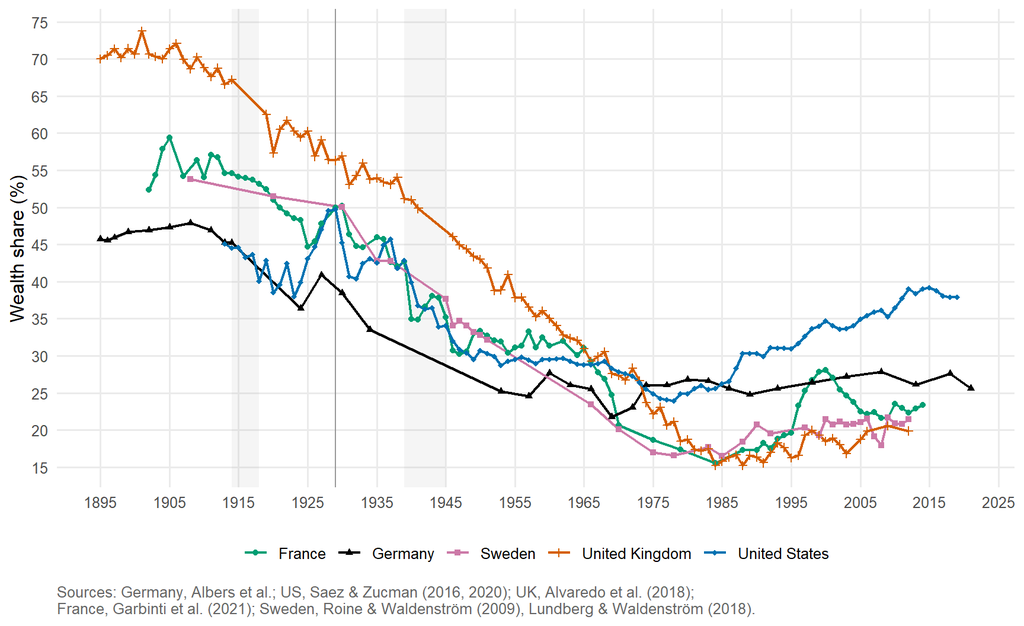

Figure 1: Top 1% share of net personal wealth (%), 1895-2021.

```r
# Okabe-Ito palette: distinguishable under common colour-vision deficiencies
cols <- c("Germany" = "#000000", "United States" = "#0072B2",
          "United Kingdom" = "#D55E00", "France" = "#009E73",
          "Sweden" = "#CC79A7")
ggplot(fig8b, aes(year, top1, colour = country, shape = country)) +
  wars +
  geom_line(linewidth = 0.8) +
  geom_point(size = 1.4) +
  scale_colour_manual(values = cols, name = NULL) +
  scale_shape_manual(values = c(16, 17, 15, 3, 18), name = NULL) +
  scale_x_continuous(breaks = seq(1895, 2025, 10)) +
  scale_y_continuous(breaks = seq(15, 75, 5)) +
  labs(x = NULL, y = "Wealth share (%)",
       caption = paste0("Sources: Germany, Albers et al.; US, Saez & Zucman (2016, 2020); ",
                        "UK, Alvaredo et al. (2018);\nFrance, Garbinti et al. (2021); ",
                        "Sweden, Roine & Waldenström (2009), Lundberg & Waldenström (2018).")) +
  theme_minimal(base_size = 12) +
  theme(legend.position = "bottom", panel.grid.minor = element_blank(),
        plot.caption = element_text(hjust = 0, colour = "grey40"))
```

## Update with WID.world

`data/WID_top1_wealth.csv` holds the top 1% wealth-share rows of the WID.world bulk file (version of 2026-09-09) for the five countries. Units are chosen to match the paper’s series: US tax units (`shwealt992`, ends 2019; matches the package within 0.18 points on average), others equal-split adults (`shwealj992`, to 2024).

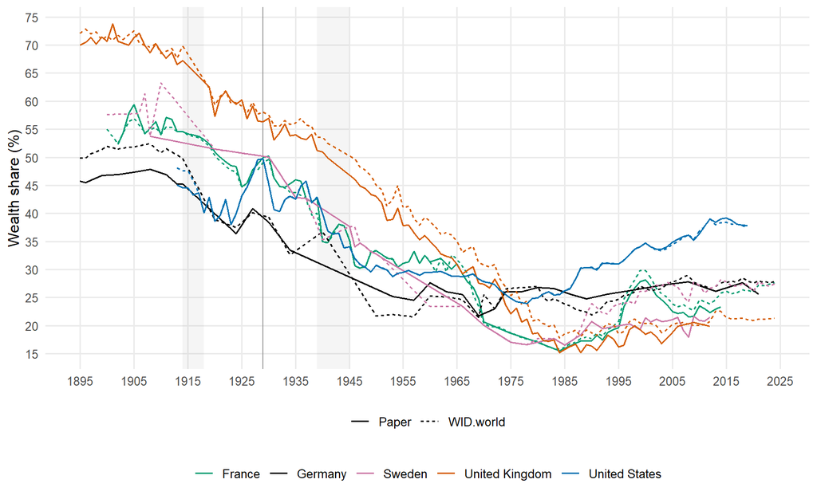

Figure 2: Top 1% wealth share (%): paper (solid) vs WID.world (dashed).

```r
wid <- fread("data/WID_top1_wealth.csv")
wid <- wid[percentile == "p99p100" &
           ((country == "US" & variable == "shwealt992") |
            (country != "US" & variable == "shwealj992")) & year >= 1895]
iso <- c(US = "United States", GB = "United Kingdom", FR = "France",
         DE = "Germany", SE = "Sweden")
wid <- wid[, .(year, country = iso[country], top1 = 100 * value, source = "WID.world")]
both <- rbind(fig8b[, .(year, country, top1, source = "Paper")], wid)
qs2::qs_save(both, "data/fig8b_paper_wid.qs2")

ggplot(both, aes(year, top1, colour = country, linetype = source)) +
  wars +
  geom_line(linewidth = 0.7) +
  scale_colour_manual(values = cols, name = NULL) +
  scale_linetype_manual(values = c(Paper = "solid", WID.world = "22"), name = NULL) +
  scale_x_continuous(breaks = seq(1895, 2025, 10)) +
  scale_y_continuous(breaks = seq(15, 75, 5)) +
  labs(x = NULL, y = "Wealth share (%)") +
  theme_minimal(base_size = 12) +
  theme(legend.position = "bottom", legend.box = "vertical",
        panel.grid.minor = element_blank())
```

## Country-level total net wealth

`Output/Totalwealth_long-run.dta` holds Germany’s aggregate net wealth (`tnw`, in billions of euro per the label at `6c_Graphics_Totals_1895-2021.do`, line 138) and national income (`ni`). It also holds net wealth as % of national income for all five countries (Fig. 8a). Germany’s ratio is `wi = 100 * tnw / ni` (`2a_Dataprep_macrodata.do`, line 237).

Table 1: Germany: total net wealth, national income and their ratio.

```r
tw <- as.data.table(haven::read_dta(file.path(src, "Output/Totalwealth_long-run.dta")))
tw <- tw[year > 1890]
de_tot <- tw[!is.na(tnw), .(year = as.integer(year), tnw, ni, wi = 100 * tnw / ni)]
print(de_tot, digits = 4, nrows = Inf)
```

```
     year     tnw      ni    wi
    <int>   <num>   <num> <num>
 1:  1895   138.3   25.23 547.9
 2:  1896   139.4   26.96 517.0
 3:  1897   142.9   28.68 498.2
 4:  1898   147.8   30.92 477.9
 5:  1899   152.8   31.62 483.3
 6:  1900   157.0   32.31 485.8
 7:  1901   161.2   31.41 513.2
 8:  1902   165.5   31.89 519.1
 9:  1903   170.4   34.20 498.3
10:  1904   175.4   35.88 489.0
11:  1905   180.6   38.68 466.9
12:  1906   187.2   40.35 464.1
13:  1907   194.1   42.97 451.7
```

[output cut: 81 more lines]

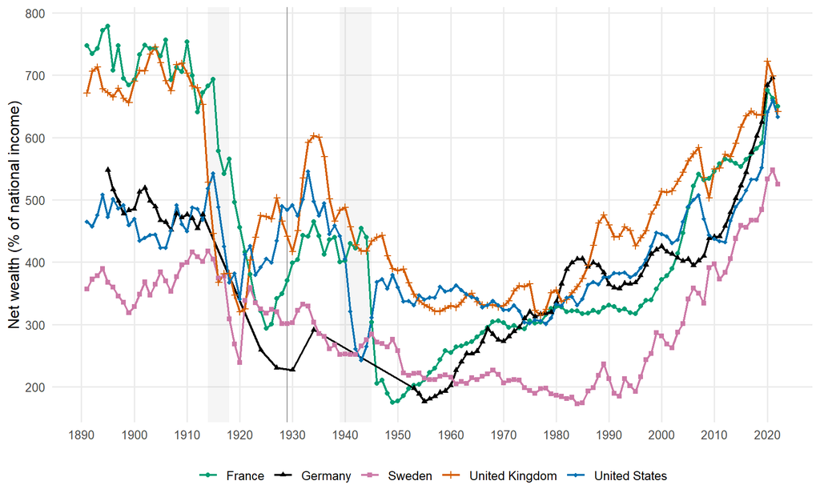

```r
wvars <- c(wi = "Germany", WI_US = "United States", WI_UK = "United Kingdom",
           WI_FR = "France", WI_SE = "Sweden")
wi <- melt(tw[, c("year", names(wvars)), with = FALSE], id.vars = "year",
           variable.name = "v", value.name = "wi", variable.factor = FALSE)
wi <- wi[!is.na(wi), .(year = as.integer(year), country = wvars[v], wi = as.numeric(wi))]
setorder(wi, country, year)
qs2::qs_save(wi, "data/fig8a_wealth_income_panel.qs2")

ggplot(wi, aes(year, wi, colour = country, shape = country)) +
  wars +
  geom_line(linewidth = 0.8) +
  geom_point(size = 1.4) +
  scale_colour_manual(values = cols, name = NULL) +
  scale_shape_manual(values = c(16, 17, 15, 3, 18), name = NULL) +
  scale_x_continuous(breaks = seq(1890, 2020, 10)) +
  scale_y_continuous(breaks = seq(0, 800, 100)) +
  labs(x = NULL, y = "Net wealth (% of national income)") +
  theme_minimal(base_size = 12) +
  theme(legend.position = "bottom", panel.grid.minor = element_blank())
```